# Optimal Treatment Analysis

## Outcome Variable

**Outcome Variable:** haz

## Predictor Variables

**Intervention Variable:** anywast06

**Adjustment Set:**

- arm
- sex
- W_mage
- meducyrs
- month
- brthmon
- delta_W_mage
- delta_meducyrs
- delta_month
- delta_brthmon

## Stratifying Variables

The analysis was stratified on these variable(s):

- agecat
- studyid
- country

## Data Summary

| agecat | studyid | country | anywast06 | n_cell | n |
| --- | --- | --- | --- | --- | --- |
| Birth | ki0047075b-MAL-ED | BANGLADESH | 0 | 198 | 255 |
| Birth | ki0047075b-MAL-ED | BANGLADESH | 1 | 57 | 255 |
| Birth | ki0047075b-MAL-ED | BRAZIL | 0 | 178 | 191 |
| Birth | ki0047075b-MAL-ED | BRAZIL | 1 | 13 | 191 |
| Birth | ki0047075b-MAL-ED | INDIA | 0 | 144 | 206 |
| Birth | ki0047075b-MAL-ED | INDIA | 1 | 62 | 206 |
| Birth | ki0047075b-MAL-ED | NEPAL | 0 | 141 | 173 |
| Birth | ki0047075b-MAL-ED | NEPAL | 1 | 32 | 173 |
| Birth | ki0047075b-MAL-ED | PERU | 0 | 275 | 286 |
| Birth | ki0047075b-MAL-ED | PERU | 1 | 11 | 286 |
| Birth | ki0047075b-MAL-ED | SOUTH AFRICA | 0 | 230 | 261 |
| Birth | ki0047075b-MAL-ED | SOUTH AFRICA | 1 | 31 | 261 |
| Birth | ki0047075b-MAL-ED | TANZANIA, UNITED REPUBLIC OF | 0 | 117 | 123 |
| Birth | ki0047075b-MAL-ED | TANZANIA, UNITED REPUBLIC OF | 1 | 6 | 123 |
| Birth | ki1000108-CMC-V-BCS-2002 | INDIA | 0 | 36 | 90 |
| Birth | ki1000108-CMC-V-BCS-2002 | INDIA | 1 | 54 | 90 |
| Birth | ki1000108-IRC | INDIA | 0 | 164 | 388 |
| Birth | ki1000108-IRC | INDIA | 1 | 224 | 388 |
| Birth | ki1000109-EE | PAKISTAN | 0 | 0 | 2 |
| Birth | ki1000109-EE | PAKISTAN | 1 | 2 | 2 |
| Birth | ki1000109-ResPak | PAKISTAN | 0 | 6 | 7 |
| Birth | ki1000109-ResPak | PAKISTAN | 1 | 1 | 7 |
| Birth | ki1101329-Keneba | GAMBIA | 0 | 1287 | 1541 |
| Birth | ki1101329-Keneba | GAMBIA | 1 | 254 | 1541 |
| Birth | ki1114097-CMIN | BANGLADESH | 0 | 5 | 8 |
| Birth | ki1114097-CMIN | BANGLADESH | 1 | 3 | 8 |
| Birth | ki1114097-CMIN | PERU | 0 | 10 | 10 |
| Birth | ki1114097-CMIN | PERU | 1 | 0 | 10 |
| Birth | ki1114097-CONTENT | PERU | 0 | 2 | 2 |
| Birth | ki1114097-CONTENT | PERU | 1 | 0 | 2 |

[output cut: 70 more lines]

The following strata were considered:

- agecat: 24 months, studyid: ki0047075b-MAL-ED, country: BANGLADESH
- agecat: 24 months, studyid: ki0047075b-MAL-ED, country: BRAZIL
- agecat: 24 months, studyid: ki0047075b-MAL-ED, country: INDIA
- agecat: 24 months, studyid: ki0047075b-MAL-ED, country: NEPAL
- agecat: 24 months, studyid: ki0047075b-MAL-ED, country: PERU
- agecat: 24 months, studyid: ki0047075b-MAL-ED, country: SOUTH AFRICA
- agecat: 24 months, studyid: ki0047075b-MAL-ED, country: TANZANIA, UNITED REPUBLIC OF
- agecat: 24 months, studyid: ki1000108-CMC-V-BCS-2002, country: INDIA
- agecat: 24 months, studyid: ki1000108-IRC, country: INDIA
- agecat: 24 months, studyid: ki1017093b-PROVIDE, country: BANGLADESH
- agecat: 24 months, studyid: ki1066203-TanzaniaChild2, country: TANZANIA, UNITED REPUBLIC OF
- agecat: 24 months, studyid: ki1101329-Keneba, country: GAMBIA
- agecat: 24 months, studyid: ki1113344-GMS-Nepal, country: NEPAL
- agecat: 24 months, studyid: ki1114097-CMIN, country: BANGLADESH
- agecat: 24 months, studyid: ki1114097-CMIN, country: PERU
- agecat: 24 months, studyid: ki1114097-CONTENT, country: PERU
- agecat: 6 months, studyid: ki0047075b-MAL-ED, country: BANGLADESH
- agecat: 6 months, studyid: ki0047075b-MAL-ED, country: BRAZIL
- agecat: 6 months, studyid: ki0047075b-MAL-ED, country: INDIA
- agecat: 6 months, studyid: ki0047075b-MAL-ED, country: NEPAL
- agecat: 6 months, studyid: ki0047075b-MAL-ED, country: PERU
- agecat: 6 months, studyid: ki0047075b-MAL-ED, country: SOUTH AFRICA
- agecat: 6 months, studyid: ki0047075b-MAL-ED, country: TANZANIA, UNITED REPUBLIC OF
- agecat: 6 months, studyid: ki1000108-CMC-V-BCS-2002, country: INDIA
- agecat: 6 months, studyid: ki1000108-IRC, country: INDIA
- agecat: 6 months, studyid: ki1000109-EE, country: PAKISTAN
- agecat: 6 months, studyid: ki1000109-ResPak, country: PAKISTAN
- agecat: 6 months, studyid: ki1017093b-PROVIDE, country: BANGLADESH
- agecat: 6 months, studyid: ki1066203-TanzaniaChild2, country: TANZANIA, UNITED REPUBLIC OF
- agecat: 6 months, studyid: ki1101329-Keneba, country: GAMBIA
- agecat: 6 months, studyid: ki1112895-Guatemala BSC, country: GUATEMALA
- agecat: 6 months, studyid: ki1113344-GMS-Nepal, country: NEPAL
- agecat: 6 months, studyid: ki1114097-CMIN, country: BANGLADESH
- agecat: 6 months, studyid: ki1114097-CMIN, country: PERU
- agecat: 6 months, studyid: ki1114097-CONTENT, country: PERU
- agecat: Birth, studyid: ki0047075b-MAL-ED, country: BANGLADESH
- agecat: Birth, studyid: ki0047075b-MAL-ED, country: BRAZIL
- agecat: Birth, studyid: ki0047075b-MAL-ED, country: INDIA
- agecat: Birth, studyid: ki0047075b-MAL-ED, country: NEPAL
- agecat: Birth, studyid: ki0047075b-MAL-ED, country: PERU
- agecat: Birth, studyid: ki0047075b-MAL-ED, country: SOUTH AFRICA
- agecat: Birth, studyid: ki0047075b-MAL-ED, country: TANZANIA, UNITED REPUBLIC OF
- agecat: Birth, studyid: ki1000108-CMC-V-BCS-2002, country: INDIA
- agecat: Birth, studyid: ki1000108-IRC, country: INDIA
- agecat: Birth, studyid: ki1000109-EE, country: PAKISTAN
- agecat: Birth, studyid: ki1000109-ResPak, country: PAKISTAN
- agecat: Birth, studyid: ki1101329-Keneba, country: GAMBIA
- agecat: Birth, studyid: ki1114097-CMIN, country: BANGLADESH
- agecat: Birth, studyid: ki1114097-CMIN, country: PERU
- agecat: Birth, studyid: ki1114097-CONTENT, country: PERU

### Dropped Strata

Some strata were dropped due to rare outcomes:

- agecat: Birth, studyid: ki1000109-EE, country: PAKISTAN
- agecat: Birth, studyid: ki1000109-ResPak, country: PAKISTAN
- agecat: Birth, studyid: ki1114097-CMIN, country: BANGLADESH
- agecat: Birth, studyid: ki1114097-CMIN, country: PERU
- agecat: Birth, studyid: ki1114097-CONTENT, country: PERU
- agecat: 6 months, studyid: ki1114097-CONTENT, country: PERU
- agecat: 24 months, studyid: ki1066203-TanzaniaChild2, country: TANZANIA, UNITED REPUBLIC OF
- agecat: 24 months, studyid: ki1114097-CONTENT, country: PERU

## Methods Detail

We’re interested in the causal parameters $E[Y_a]$ for all values of $a \in \mathcal{A}$. These parameters represent the mean outcome if, possibly contrary to fact, we intervened to set all units to have $A=a$. Under the randomization and positivity assumptions, these are identified by the statistical parameters $\psi_a=E_W[E_{Y|A,W}(Y|A=a,W)]$. In addition, we’re interested in the mean of $Y$, $E[Y]$ under no intervention (the observed mean). We will estimate these parameters by using SuperLearner to fit the relevant likelihood factors – $E_{Y|A,W}(Y|A=a,W)$ and $p(A=a|W)$, and then updating our likelihood fit using a joint TMLE.

For unadjusted analyses ($W=\{\}$), initial likelihoods were estimated using Lrnr_glm to estimate the simple $E(Y|A)$ and Lrnr_mean to estimate $p(A)$. For adjusted analyses, a small library containing Lrnr_glmnet, Lrnr_xgboost, and Lrnr_mean was used.

Having estimated these parameters, we will then use the delta method to estimate relative risks and attributable risks relative to a prespecified baseline level of $A$.

# Results Detail

## Results Plots

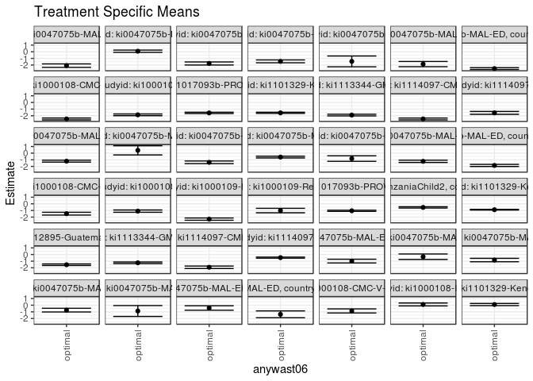

## Results Table

### Parameter: TSM

| agecat | studyid | country | intervention_level | baseline_level | estimate | ci_lower | ci_upper |
| --- | --- | --- | --- | --- | --- | --- | --- |
| Birth | ki0047075b-MAL-ED | BANGLADESH | optimal | observed | -0.9891685 | -1.2721705 | -0.7061665 |
| Birth | ki0047075b-MAL-ED | BRAZIL | optimal | observed | -0.3308356 | -0.7436766 | 0.0820054 |
| Birth | ki0047075b-MAL-ED | INDIA | optimal | observed | -0.8332657 | -1.0914488 | -0.5750826 |
| Birth | ki0047075b-MAL-ED | NEPAL | optimal | observed | -0.7414976 | -1.0206071 | -0.4623880 |
| Birth | ki0047075b-MAL-ED | PERU | optimal | observed | -0.8728929 | -1.6932319 | -0.0525540 |
| Birth | ki0047075b-MAL-ED | SOUTH AFRICA | optimal | observed | -0.4194691 | -0.7547462 | -0.0841920 |
| Birth | ki0047075b-MAL-ED | TANZANIA, UNITED REPUBLIC OF | optimal | observed | -1.3758995 | -1.8894745 | -0.8623244 |
| Birth | ki1000108-CMC-V-BCS-2002 | INDIA | optimal | observed | -0.8641823 | -1.1715769 | -0.5567876 |
| Birth | ki1000108-IRC | INDIA | optimal | observed | 0.1132273 | -0.1057031 | 0.3321577 |
| Birth | ki1101329-Keneba | GAMBIA | optimal | observed | 0.0994548 | -0.0634077 | 0.2623172 |
| 6 months | ki0047075b-MAL-ED | BANGLADESH | optimal | observed | -1.2108894 | -1.3541235 | -1.0676554 |
| 6 months | ki0047075b-MAL-ED | BRAZIL | optimal | observed | 0.4223002 | -0.2704067 | 1.1150071 |
| 6 months | ki0047075b-MAL-ED | INDIA | optimal | observed | -1.3842465 | -1.5851207 | -1.1833723 |
| 6 months | ki0047075b-MAL-ED | NEPAL | optimal | observed | -0.5938275 | -0.7258254 | -0.4618297 |
| 6 months | ki0047075b-MAL-ED | PERU | optimal | observed | -0.8182292 | -1.2307655 | -0.4056929 |
| 6 months | ki0047075b-MAL-ED | SOUTH AFRICA | optimal | observed | -1.2335853 | -1.4040240 | -1.0631467 |
| 6 months | ki0047075b-MAL-ED | TANZANIA, UNITED REPUBLIC OF | optimal | observed | -1.8525097 | -2.0093066 | -1.6957127 |
| 6 months | ki1000108-CMC-V-BCS-2002 | INDIA | optimal | observed | -1.4821921 | -1.6934176 | -1.2709665 |
| 6 months | ki1000108-IRC | INDIA | optimal | observed | -1.0993737 | -1.2718556 | -0.9268918 |
| 6 months | ki1000109-EE | PAKISTAN | optimal | observed | -2.3059315 | -2.4781345 | -2.1337284 |
| 6 months | ki1000109-ResPak | PAKISTAN | optimal | observed | -1.0112670 | -1.3493486 | -0.6731855 |
| 6 months | ki1017093b-PROVIDE | BANGLADESH | optimal | observed | -1.0476660 | -1.1356147 | -0.9597173 |
| 6 months | ki1066203-TanzaniaChild2 | TANZANIA, UNITED REPUBLIC OF | optimal | observed | -0.5382562 | -0.6371761 | -0.4393363 |
| 6 months | ki1101329-Keneba | GAMBIA | optimal | observed | -0.8853752 | -0.9346347 | -0.8361157 |
| 6 months | ki1112895-Guatemala BSC | GUATEMALA | optimal | observed | -1.5383715 | -1.6548610 | -1.4218821 |
| 6 months | ki1113344-GMS-Nepal | NEPAL | optimal | observed | -1.2498986 | -1.3738940 | -1.1259031 |
| 6 months | ki1114097-CMIN | BANGLADESH | optimal | observed | -1.9230147 | -2.1115567 | -1.7344727 |
| 6 months | ki1114097-CMIN | PERU | optimal | observed | -0.4708548 | -0.5483883 | -0.3933213 |
| 24 months | ki0047075b-MAL-ED | BANGLADESH | optimal | observed | -2.0873357 | -2.3479679 | -1.8267034 |
| 24 months | ki0047075b-MAL-ED | BRAZIL | optimal | observed | 0.0814286 | -0.0909571 | 0.2538144 |
| 24 months | ki0047075b-MAL-ED | INDIA | optimal | observed | -1.7622844 | -1.9937434 | -1.5308254 |
| 24 months | ki0047075b-MAL-ED | NEPAL | optimal | observed | -1.4464410 | -1.6600494 | -1.2328327 |
| 24 months | ki0047075b-MAL-ED | PERU | optimal | observed | -1.4510596 | -2.2642115 | -0.6379076 |
| 24 months | ki0047075b-MAL-ED | SOUTH AFRICA | optimal | observed | -1.8590801 | -2.2537954 | -1.4643647 |
| 24 months | ki0047075b-MAL-ED | TANZANIA, UNITED REPUBLIC OF | optimal | observed | -2.5346222 | -2.6754091 | -2.3938352 |
| 24 months | ki1000108-CMC-V-BCS-2002 | INDIA | optimal | observed | -2.4863174 | -2.6304678 | -2.3421671 |
| 24 months | ki1000108-IRC | INDIA | optimal | observed | -1.8656844 | -1.9933979 | -1.7379709 |
| 24 months | ki1017093b-PROVIDE | BANGLADESH | optimal | observed | -1.5727046 | -1.6727542 | -1.4726549 |
| 24 months | ki1101329-Keneba | GAMBIA | optimal | observed | -1.5662482 | -1.6565050 | -1.4759914 |
| 24 months | ki1113344-GMS-Nepal | NEPAL | optimal | observed | -1.8998976 | -2.0278808 | -1.7719145 |
| 24 months | ki1114097-CMIN | BANGLADESH | optimal | observed | -2.4860341 | -2.6239171 | -2.3481511 |
| 24 months | ki1114097-CMIN | PERU | optimal | observed | -1.5702337 | -1.7858726 | -1.3545948 |

### Parameter: E(Y)

| agecat | studyid | country | intervention_level | baseline_level | estimate | ci_lower | ci_upper |
| --- | --- | --- | --- | --- | --- | --- | --- |
| Birth | ki0047075b-MAL-ED | BANGLADESH | observed | observed | -1.0715686 | -1.1969582 | -0.9461791 |
| Birth | ki0047075b-MAL-ED | BRAZIL | observed | observed | -0.7609424 | -0.9178311 | -0.6040538 |
| Birth | ki0047075b-MAL-ED | INDIA | observed | observed | -1.0106311 | -1.1499962 | -0.8712660 |
| Birth | ki0047075b-MAL-ED | NEPAL | observed | observed | -0.7089017 | -0.8656064 | -0.5521971 |
| Birth | ki0047075b-MAL-ED | PERU | observed | observed | -0.9163986 | -1.0263706 | -0.8064266 |
| Birth | ki0047075b-MAL-ED | SOUTH AFRICA | observed | observed | -0.7064368 | -0.8290380 | -0.5838355 |
| Birth | ki0047075b-MAL-ED | TANZANIA, UNITED REPUBLIC OF | observed | observed | -0.9338211 | -1.1465079 | -0.7211344 |
| Birth | ki1000108-CMC-V-BCS-2002 | INDIA | observed | observed | -0.9654444 | -1.1742112 | -0.7566777 |
| Birth | ki1000108-IRC | INDIA | observed | observed | -0.3080412 | -0.4687931 | -0.1472894 |
| Birth | ki1101329-Keneba | GAMBIA | observed | observed | 0.0341467 | -0.0293905 | 0.0976838 |
| 6 months | ki0047075b-MAL-ED | BANGLADESH | observed | observed | -1.2056777 | -1.3231497 | -1.0882058 |
| 6 months | ki0047075b-MAL-ED | BRAZIL | observed | observed | 0.0510207 | -0.0930194 | 0.1950608 |
| 6 months | ki0047075b-MAL-ED | INDIA | observed | observed | -1.2203672 | -1.3387619 | -1.1019726 |
| 6 months | ki0047075b-MAL-ED | NEPAL | observed | observed | -0.5610593 | -0.6737915 | -0.4483272 |
| 6 months | ki0047075b-MAL-ED | PERU | observed | observed | -1.3268010 | -1.4351217 | -1.2184802 |
| 6 months | ki0047075b-MAL-ED | SOUTH AFRICA | observed | observed | -1.0633760 | -1.1911088 | -0.9356432 |
| 6 months | ki0047075b-MAL-ED | TANZANIA, UNITED REPUBLIC OF | observed | observed | -1.3601215 | -1.4821830 | -1.2380600 |
| 6 months | ki1000108-CMC-V-BCS-2002 | INDIA | observed | observed | -1.4251321 | -1.5673802 | -1.2828839 |
| 6 months | ki1000108-IRC | INDIA | observed | observed | -1.2344062 | -1.3658524 | -1.1029600 |
| 6 months | ki1000109-EE | PAKISTAN | observed | observed | -2.2004704 | -2.3234073 | -2.0775336 |
| 6 months | ki1000109-ResPak | PAKISTAN | observed | observed | -1.4029220 | -1.6085859 | -1.1972581 |
| 6 months | ki1017093b-PROVIDE | BANGLADESH | observed | observed | -1.0871041 | -1.1635539 | -1.0106543 |
| 6 months | ki1066203-TanzaniaChild2 | TANZANIA, UNITED REPUBLIC OF | observed | observed | -0.5434389 | -0.5924056 | -0.4944722 |
| 6 months | ki1101329-Keneba | GAMBIA | observed | observed | -0.9121372 | -0.9593127 | -0.8649617 |
| 6 months | ki1112895-Guatemala BSC | GUATEMALA | observed | observed | -1.5785476 | -1.6926664 | -1.4644288 |
| 6 months | ki1113344-GMS-Nepal | NEPAL | observed | observed | -1.3321522 | -1.4103691 | -1.2539352 |
| 6 months | ki1114097-CMIN | BANGLADESH | observed | observed | -1.7844376 | -1.9222926 | -1.6465825 |
| 6 months | ki1114097-CMIN | PERU | observed | observed | -0.5098299 | -0.5892202 | -0.4304395 |
| 24 months | ki0047075b-MAL-ED | BANGLADESH | observed | observed | -1.9431132 | -2.0691678 | -1.8170586 |
| 24 months | ki0047075b-MAL-ED | BRAZIL | observed | observed | 0.0418343 | -0.1253834 | 0.2090521 |
| 24 months | ki0047075b-MAL-ED | INDIA | observed | observed | -1.8458150 | -1.9718703 | -1.7197596 |
| 24 months | ki0047075b-MAL-ED | NEPAL | observed | observed | -1.2752193 | -1.3954783 | -1.1549603 |
| 24 months | ki0047075b-MAL-ED | PERU | observed | observed | -1.7500995 | -1.8705474 | -1.6296516 |
| 24 months | ki0047075b-MAL-ED | SOUTH AFRICA | observed | observed | -1.6228361 | -1.7581177 | -1.4875546 |
| 24 months | ki0047075b-MAL-ED | TANZANIA, UNITED REPUBLIC OF | observed | observed | -2.6058879 | -2.7403043 | -2.4714714 |
| 24 months | ki1000108-CMC-V-BCS-2002 | INDIA | observed | observed | -2.5530299 | -2.6529925 | -2.4530672 |
| 24 months | ki1000108-IRC | INDIA | observed | observed | -1.7824776 | -1.8765600 | -1.6883952 |
| 24 months | ki1017093b-PROVIDE | BANGLADESH | observed | observed | -1.5861179 | -1.6693668 | -1.5028689 |
| 24 months | ki1101329-Keneba | GAMBIA | observed | observed | -1.5604961 | -1.6126979 | -1.5082943 |
| 24 months | ki1113344-GMS-Nepal | NEPAL | observed | observed | -1.8835905 | -1.9681499 | -1.7990312 |
| 24 months | ki1114097-CMIN | BANGLADESH | observed | observed | -2.5109504 | -2.6361514 | -2.3857494 |
| 24 months | ki1114097-CMIN | PERU | observed | observed | -1.4696439 | -1.5956384 | -1.3436493 |

### Parameter: PAR

| agecat | studyid | country | intervention_level | baseline_level | estimate | ci_lower | ci_upper |
| --- | --- | --- | --- | --- | --- | --- | --- |
| Birth | ki0047075b-MAL-ED | BANGLADESH | optimal | observed | -0.0824001 | -0.3247483 | 0.1599480 |
| Birth | ki0047075b-MAL-ED | BRAZIL | optimal | observed | -0.4301068 | -0.8460423 | -0.0141713 |
| Birth | ki0047075b-MAL-ED | INDIA | optimal | observed | -0.1773654 | -0.3952040 | 0.0404733 |
| Birth | ki0047075b-MAL-ED | NEPAL | optimal | observed | 0.0325959 | -0.1948431 | 0.2600348 |
| Birth | ki0047075b-MAL-ED | PERU | optimal | observed | -0.0435057 | -0.8353671 | 0.7483558 |
| Birth | ki0047075b-MAL-ED | SOUTH AFRICA | optimal | observed | -0.2869677 | -0.5916844 | 0.0177490 |
| Birth | ki0047075b-MAL-ED | TANZANIA, UNITED REPUBLIC OF | optimal | observed | 0.4420783 | -0.0906678 | 0.9748245 |
| Birth | ki1000108-CMC-V-BCS-2002 | INDIA | optimal | observed | -0.1012622 | -0.3530039 | 0.1504795 |
| Birth | ki1000108-IRC | INDIA | optimal | observed | -0.4212685 | -0.5598243 | -0.2827128 |
| Birth | ki1101329-Keneba | GAMBIA | optimal | observed | -0.0653081 | -0.2086994 | 0.0780832 |
| 6 months | ki0047075b-MAL-ED | BANGLADESH | optimal | observed | 0.0052117 | -0.0856110 | 0.0960345 |
| 6 months | ki0047075b-MAL-ED | BRAZIL | optimal | observed | -0.3712795 | -1.0421930 | 0.2996340 |
| 6 months | ki0047075b-MAL-ED | INDIA | optimal | observed | 0.1638793 | 0.0209470 | 0.3068116 |
| 6 months | ki0047075b-MAL-ED | NEPAL | optimal | observed | 0.0327682 | -0.0703943 | 0.1359307 |
| 6 months | ki0047075b-MAL-ED | PERU | optimal | observed | -0.5085718 | -0.9098972 | -0.1072464 |
| 6 months | ki0047075b-MAL-ED | SOUTH AFRICA | optimal | observed | 0.1702094 | 0.0714000 | 0.2690187 |
| 6 months | ki0047075b-MAL-ED | TANZANIA, UNITED REPUBLIC OF | optimal | observed | 0.4923882 | 0.3595024 | 0.6252740 |
| 6 months | ki1000108-CMC-V-BCS-2002 | INDIA | optimal | observed | 0.0570600 | -0.0934938 | 0.2076138 |
| 6 months | ki1000108-IRC | INDIA | optimal | observed | -0.1350325 | -0.2445659 | -0.0254992 |
| 6 months | ki1000109-EE | PAKISTAN | optimal | observed | 0.1054610 | -0.0137311 | 0.2246532 |
| 6 months | ki1000109-ResPak | PAKISTAN | optimal | observed | -0.3916550 | -0.6481242 | -0.1351858 |
| 6 months | ki1017093b-PROVIDE | BANGLADESH | optimal | observed | -0.0394380 | -0.0857831 | 0.0069070 |
| 6 months | ki1066203-TanzaniaChild2 | TANZANIA, UNITED REPUBLIC OF | optimal | observed | -0.0051827 | -0.0893880 | 0.0790226 |
| 6 months | ki1101329-Keneba | GAMBIA | optimal | observed | -0.0267620 | -0.0525172 | -0.0010069 |
| 6 months | ki1112895-Guatemala BSC | GUATEMALA | optimal | observed | -0.0401761 | -0.0734036 | -0.0069486 |
| 6 months | ki1113344-GMS-Nepal | NEPAL | optimal | observed | -0.0822536 | -0.1865237 | 0.0220165 |
| 6 months | ki1114097-CMIN | BANGLADESH | optimal | observed | 0.1385771 | 0.0044751 | 0.2726791 |
| 6 months | ki1114097-CMIN | PERU | optimal | observed | -0.0389751 | -0.0731824 | -0.0047678 |
| 24 months | ki0047075b-MAL-ED | BANGLADESH | optimal | observed | 0.1442225 | -0.0736378 | 0.3620827 |
| 24 months | ki0047075b-MAL-ED | BRAZIL | optimal | observed | -0.0395943 | -0.0895955 | 0.0104069 |
| 24 months | ki0047075b-MAL-ED | INDIA | optimal | observed | -0.0835306 | -0.2675908 | 0.1005297 |
| 24 months | ki0047075b-MAL-ED | NEPAL | optimal | observed | 0.1712217 | 0.0076894 | 0.3347540 |
| 24 months | ki0047075b-MAL-ED | PERU | optimal | observed | -0.2990399 | -1.0926974 | 0.4946175 |
| 24 months | ki0047075b-MAL-ED | SOUTH AFRICA | optimal | observed | 0.2362439 | -0.1368969 | 0.6093848 |
| 24 months | ki0047075b-MAL-ED | TANZANIA, UNITED REPUBLIC OF | optimal | observed | -0.0712657 | -0.1355471 | -0.0069843 |
| 24 months | ki1000108-CMC-V-BCS-2002 | INDIA | optimal | observed | -0.0667125 | -0.1699650 | 0.0365401 |
| 24 months | ki1000108-IRC | INDIA | optimal | observed | 0.0832068 | -0.0060737 | 0.1724873 |
| 24 months | ki1017093b-PROVIDE | BANGLADESH | optimal | observed | -0.0134133 | -0.0583779 | 0.0315513 |
| 24 months | ki1101329-Keneba | GAMBIA | optimal | observed | 0.0057521 | -0.0636117 | 0.0751160 |
| 24 months | ki1113344-GMS-Nepal | NEPAL | optimal | observed | 0.0163071 | -0.0806007 | 0.1132149 |
| 24 months | ki1114097-CMIN | BANGLADESH | optimal | observed | -0.0249163 | -0.0814444 | 0.0316117 |
| 24 months | ki1114097-CMIN | PERU | optimal | observed | 0.1005898 | -0.0772441 | 0.2784238 |